# 2021 경제인문사회연구회 맞춤형

## Quantile regression

- 평균이 아닌 중위수를 이용한 회귀모형은 이상치에 영항을 많이 받지 않음
- quantreg 패키지를 설치 후 rq 함수를 사용하면 됩니다.

```r
if(!require(quantreg)) install.packages("quantreg", repos = "http://cran.us.r-project.org"); library(quantreg)
data(mtcars)

rqfit <- rq(mpg ~ wt, data = mtcars)
rqfit
```

```
## Call:
## rq(formula = mpg ~ wt, data = mtcars)
##
## Coefficients:
## (Intercept)          wt
##   34.232237   -4.539474
##
## Degrees of freedom: 32 total; 30 residual
```

```r
summary(rqfit)
```

```
##
## Call: rq(formula = mpg ~ wt, data = mtcars)
##
## tau: [1] 0.5
##
## Coefficients:
##             coefficients lower bd upper bd
## (Intercept) 34.23224     32.25029 39.74085
## wt          -4.53947     -6.47553 -4.16390
```

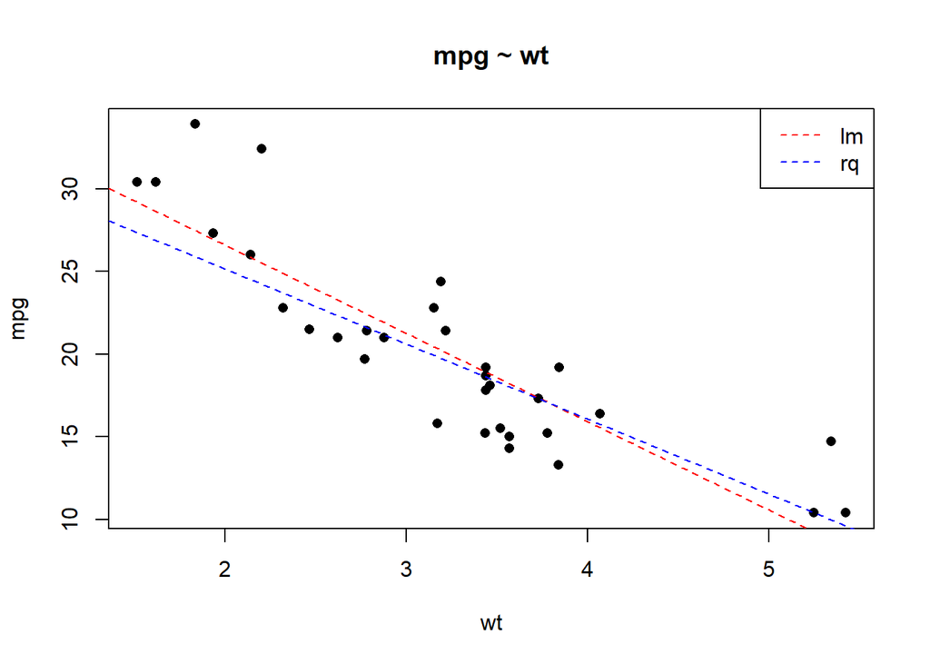

```r
plot(mpg ~ wt, data = mtcars, pch = 16, main = "mpg ~ wt")
abline(lm(mpg ~ wt, data = mtcars), col = "red", lty = 2)
abline(rq(mpg ~ wt, data = mtcars), col = "blue", lty = 2)
legend("topright", legend = c("lm", "rq"), col = c("red","blue"), lty=2)
```

자료에 이상치를 추가해 보겠습니다.

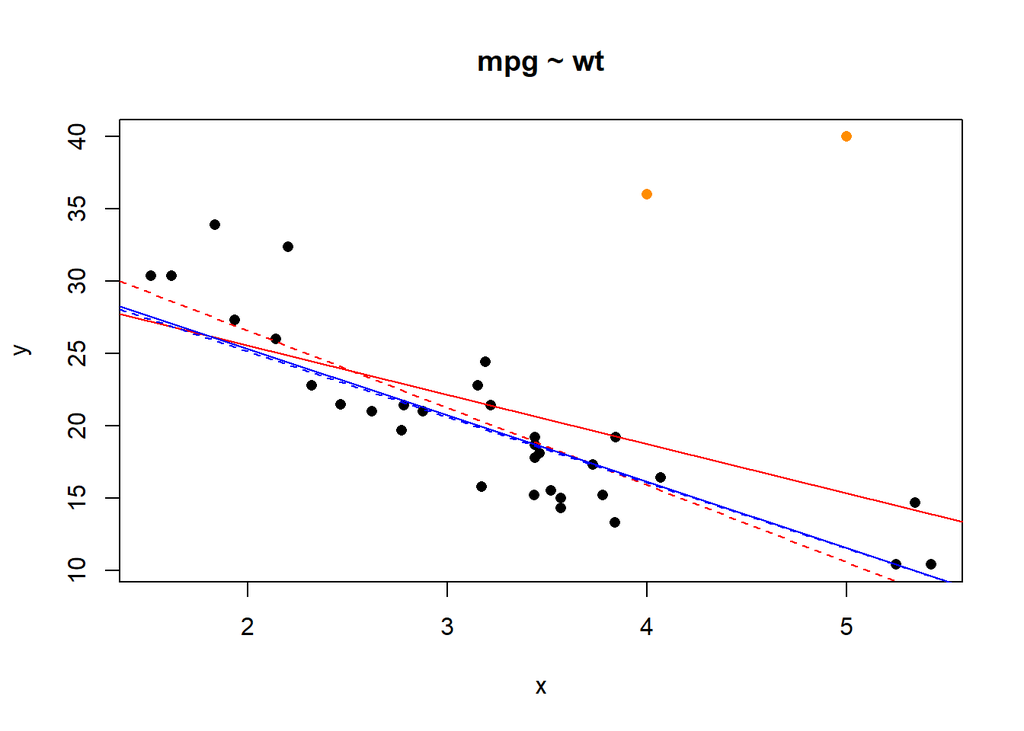

```r
y <- c(mtcars$mpg, 40, 36)
x <- c(mtcars$wt, 5, 4)
plot(y ~ x, pch = 16, main = "mpg ~ wt")
points(c(5, 4), c(40, 36), pch = 16, col = "dark orange")
abline(lm(mpg ~ wt, data = mtcars), col = "red", lty = 2)
abline(lm(y ~ x), col = "red")
# 이상치가 추가되어 추정된 선이 많이 변화된 것을 확인할 수 있음

abline(rq(mpg ~ wt, data = mtcars), col = "blue", lty = 2)
abline(rq(y ~ x), col = "blue")
```

```r
# 분위수(중위수) 회귀의 경우 이상치가 포함되더라도 결과에 영향을 많이 받지 않음.
```

- 기본 분위 즉, tau=0.5 중위수이지만 아래와 같이 여러 분위별 모형도 세울 수 있음.

```r
multi_rqfit <- rq(mpg ~ wt, data = mtcars, tau = seq(0, 1, by = 0.1))
multi_rqfit
```

```
## Call:
## rq(formula = mpg ~ wt, tau = seq(0, 1, by = 0.1), data = mtcars)
##
## Coefficients:
##             tau= 0.0  tau= 0.1 tau= 0.2  tau= 0.3  tau= 0.4  tau= 0.5  tau= 0.6
## (Intercept)  27.6875 37.509794  37.2768 34.876712 34.891176 34.232237 36.734405
## wt           -3.7500 -6.494845  -6.2400 -5.205479 -4.852941 -4.539474 -5.016077
##              tau= 0.7  tau= 0.8  tau= 0.9  tau= 1.0
## (Intercept) 38.497404 38.879916 44.391047 44.781558
## wt          -5.351887 -5.250722 -6.266786 -5.627981
##
## Degrees of freedom: 32 total; 30 residual
```

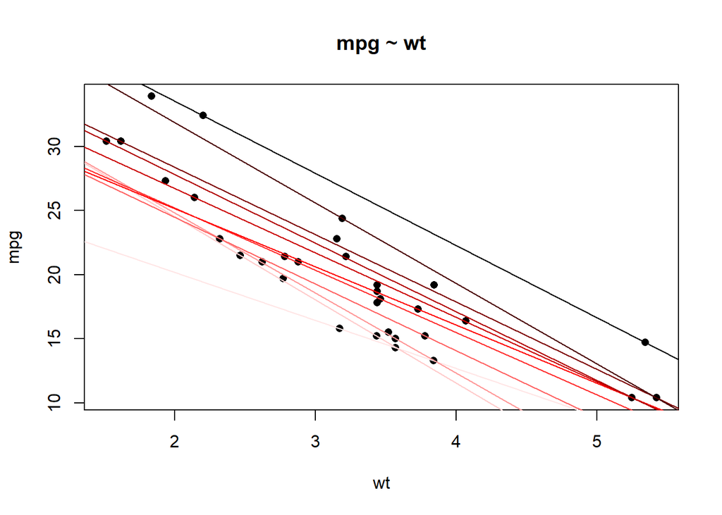

```r
# plotting different quantiles
colors <- c("#ffe6e6", "#ffcccc", "#ff9999", "#ff6666", "#ff3333",
            "#ff0000", "#cc0000", "#b30000", "#800000", "#4d0000", "#000000")

plot(mpg ~ wt, data = mtcars, pch = 16, main = "mpg ~ wt")
for (j in 1:ncol(multi_rqfit$coefficients)) {
  abline(coef(multi_rqfit)[, j], col = colors[j])
}
```

## 분위수 회귀모형의 응용

- 2011-2012 질병관리센터 국가보건영양검사에서 얻은 인체측정학적 데이터를 분석해보자.
- 키, 몸무게, 나이, 성별 간의 관계를 알고싶다.

```r
body <- read.csv("https://scholar.harvard.edu/files/gerrard/files/nhanes_body.txt")

dim(body) # 총 8,602개의 자료, 5개의 변수
```

```
## [1] 8602    5
```

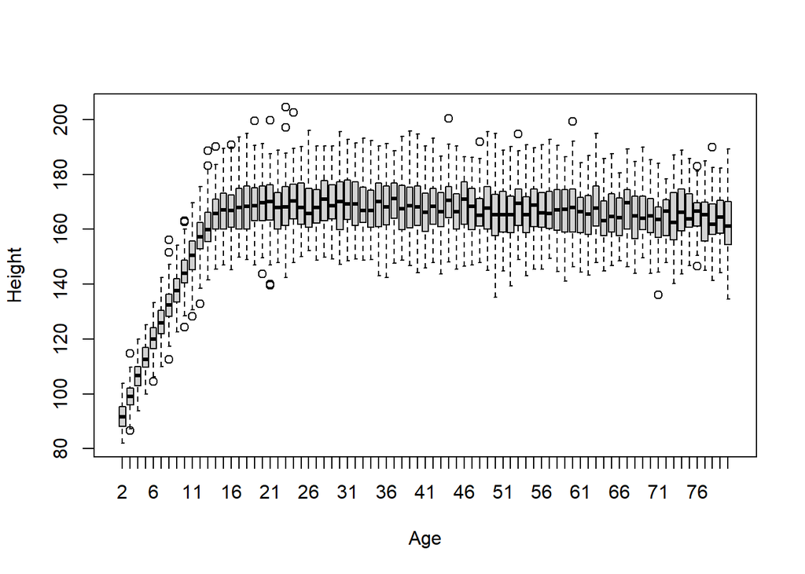

```r
boxplot(body$height~body$age, xlab='Age', ylab='Height')
```

유년기와 성년기를 18세를 기준으로 구분하여 접근하겠습니다.

키 성장곡선은 선형보다는 3차 선형식에 적합하므로 3차 선형모형으로 접근합니다.

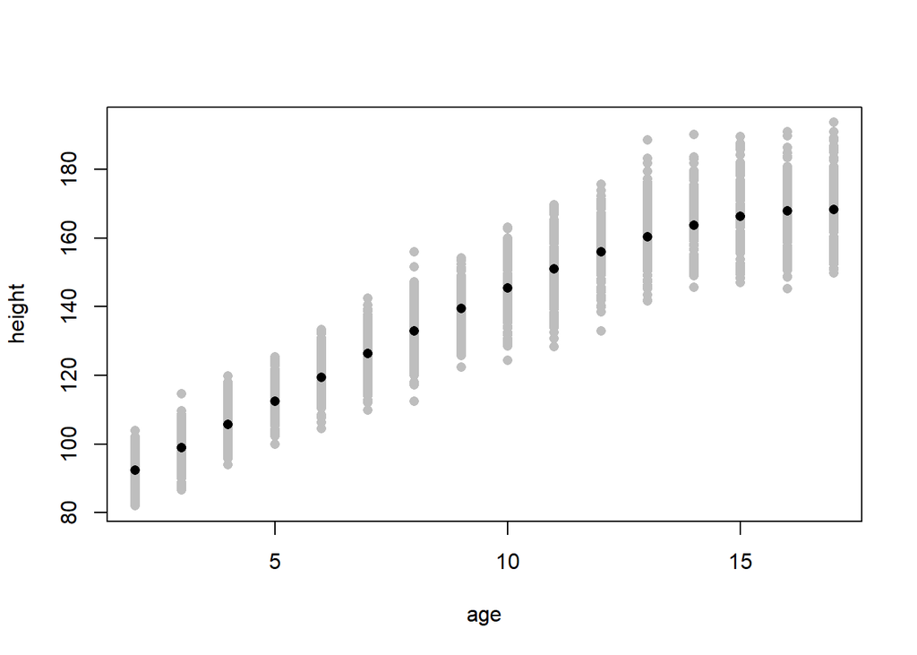

```r
youths <- body[body$age<18,]
adults <- body[body$age>=18,]

fit.youths.l3 <- lm(height~age+I(age^2)+I(age^3), data=youths)
plot(height~age, data=youths, pch=16, col="gray")
points(youths$age, fit.youths.l3$fitted.values, pch=16)
```

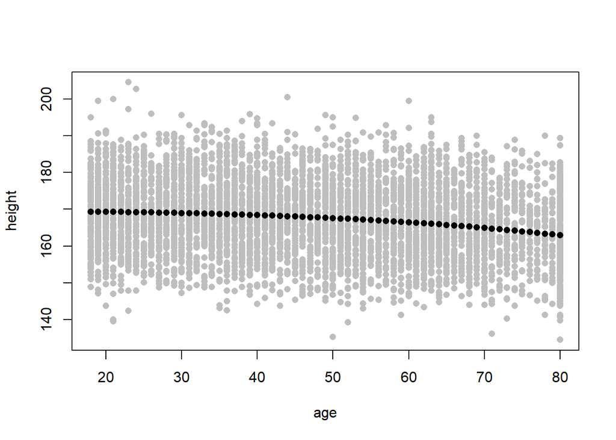

```r
fit.adults.l3 <- lm(height~age+I(age^2)+I(age^3), data=adults)
plot(height~age, data=adults, pch=16, col="gray")
points(adults$age, fit.adults.l3$fitted.values, pch=16)
```

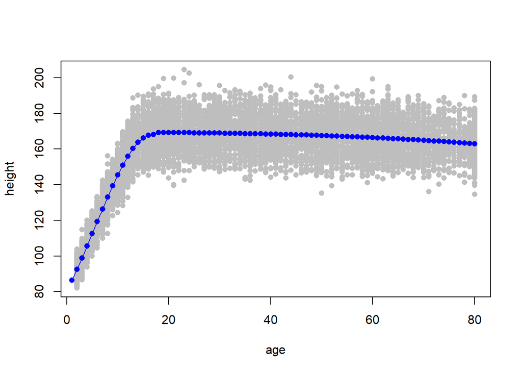

```r
plot(height~age, data=rbind(youths,adults), pch=16, col="gray")
y1<-predict(fit.youths.l3, newdata=data.frame(age=1:17))
y2<-predict(fit.adults.l3, newdata=data.frame(age=18:80))
lines(1:80, c(y1,y2), col="blue", type="o", pch=16)
```

- 위의 결과를 분위수 회귀모형을 통해 상위 10% 사람들 혹은 하위 10% 사람들에 대한 곡선을 추가해보자.

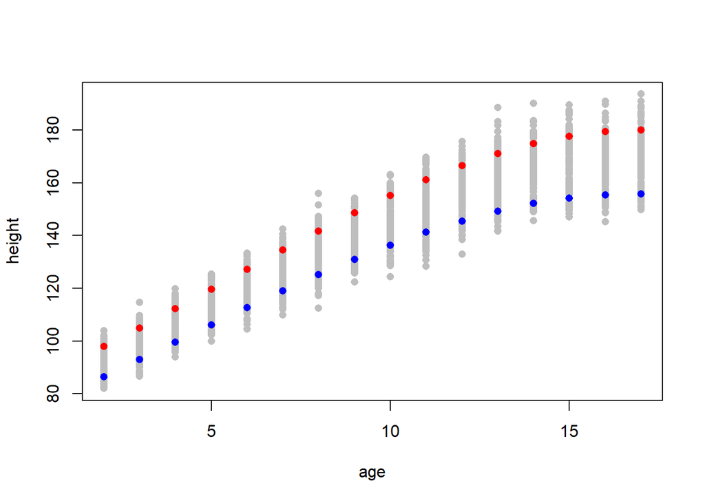

```r
fit.youths.10 <- rq(height~age+I(age^2)+I(age^3), data=youths, tau=c(0.1,0.9))
plot(height~age, data=youths, pch=16, col="gray")
points(youths$age, fit.youths.10$fitted.values[,1], pch=16, col="blue")
points(youths$age, fit.youths.10$fitted.values[,2], pch=16, col="red")
```

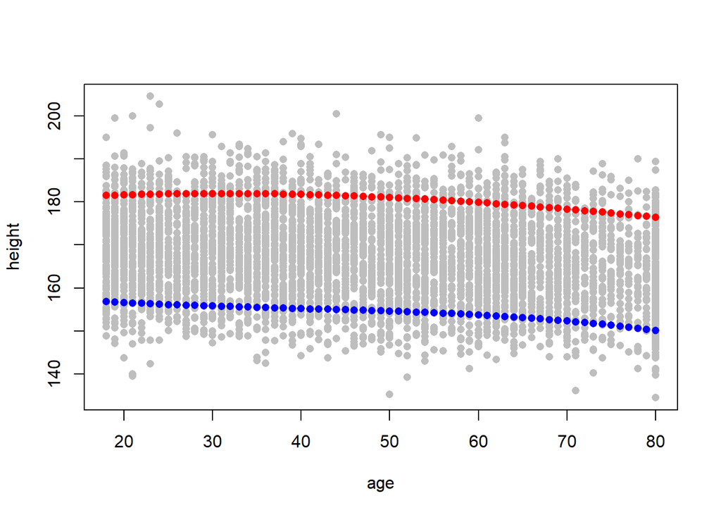

```r
fit.adults.10 <- rq(height~age+I(age^2)+I(age^3), data=adults, tau=c(0.1,0.9))
plot(height~age, data=adults, pch=16, col="gray")
points(adults$age, fit.adults.10$fitted.values[,1], pch=16, col="blue")
points(adults$age, fit.adults.10$fitted.values[,2], pch=16, col="red")
```

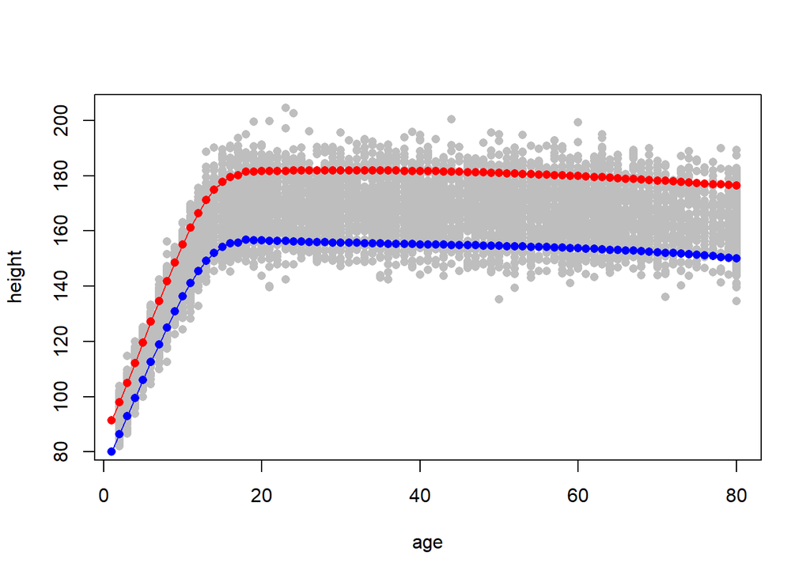

```r
plot(height~age, data=rbind(youths,adults), pch=16, col="gray")
y1<-predict(fit.youths.10, newdata=data.frame(age=1:17))
y2<-predict(fit.adults.10, newdata=data.frame(age=18:80))
lines(1:80, c(y1[,1],y2[,1]), col="blue", type="o", pch=16)
lines(1:80, c(y1[,2],y2[,2]), col="red", type="o", pch=16)
```

### 비선형 회귀모형

- 2010 윤홍배(2010)-가축분퇴비가_연용된_밭_토양에서_잠재적_질소_무기화량_추정 (002).pdf

비선형 회귀모형은 지수함수, 또는 로그함수가 선형식에 들어간 특수 형태입니다.

```r
if(!require(nls2))install.packages("nls2")
library(nls2)
if(!require(easynls))install.packages("easynls")
library(easynls)
```

- 임의의 데이터 생성

```r
time1 <- c(0,5,10,20,40,80,100,130,150,200)
y <- 12.50*(1-exp(-0.01228*time1))+rnorm(10)*1
data1 <- data.frame(time1,y)
```

$$y = 12.50 \times (1- \exp(-0.01228 \times time)) + \epsilon$$
- true value a=12.50, b=0.01228

실제 자료는 아래와 같습니다.

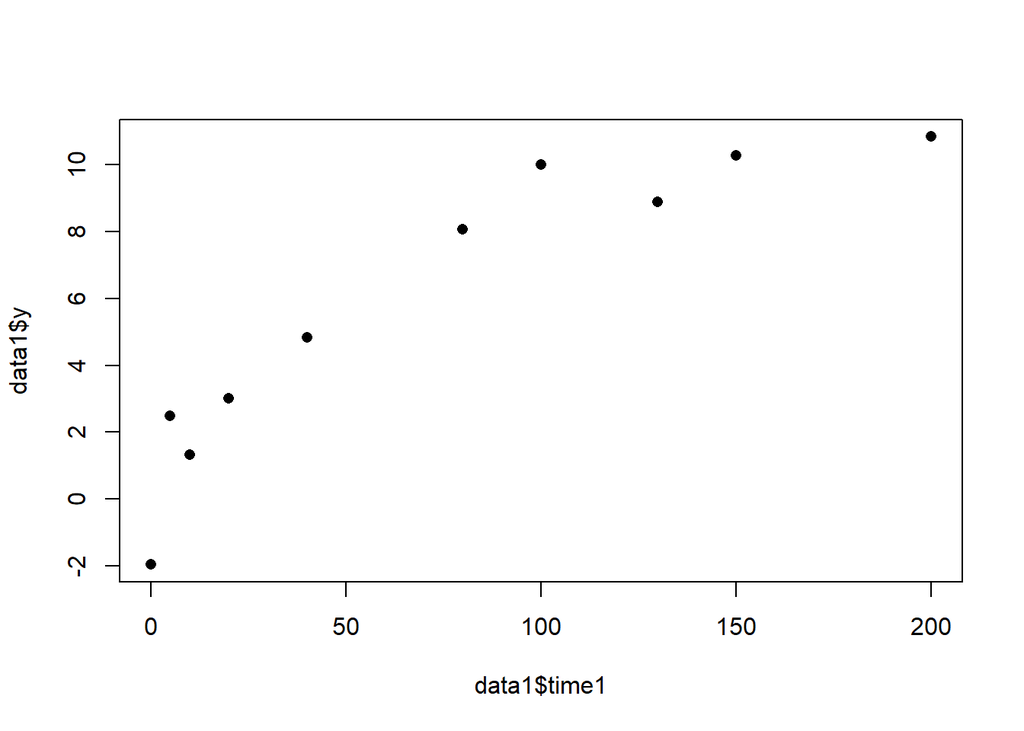

```r
plot(data1$time1, data1$y, pch=16) #자료를 그림으로 표
```

이제 r을 통해서 위 곡선과 유사한 비선형식을 추정해보겠습니다.

- 방법 1

```r
nlsfit(data1, model=9, start=c(10,1,0.01))
```

```
## $Model
## [1] "y~a*(1-b*(exp(-c*x)))"
##
## $Parameters
##                                y
## coefficient a        10.90206363
## coefficient b         1.04362467
## coefficient c         0.01820733
## p-value t.test for a  0.00001686
## p-value t.test for b  0.00000162
## p-value t.test for c  0.01363066
## r-squared             0.95340000
## adjusted r-squared    0.94000000
## AIC                  34.50837293
## BIC                  35.71871330
```

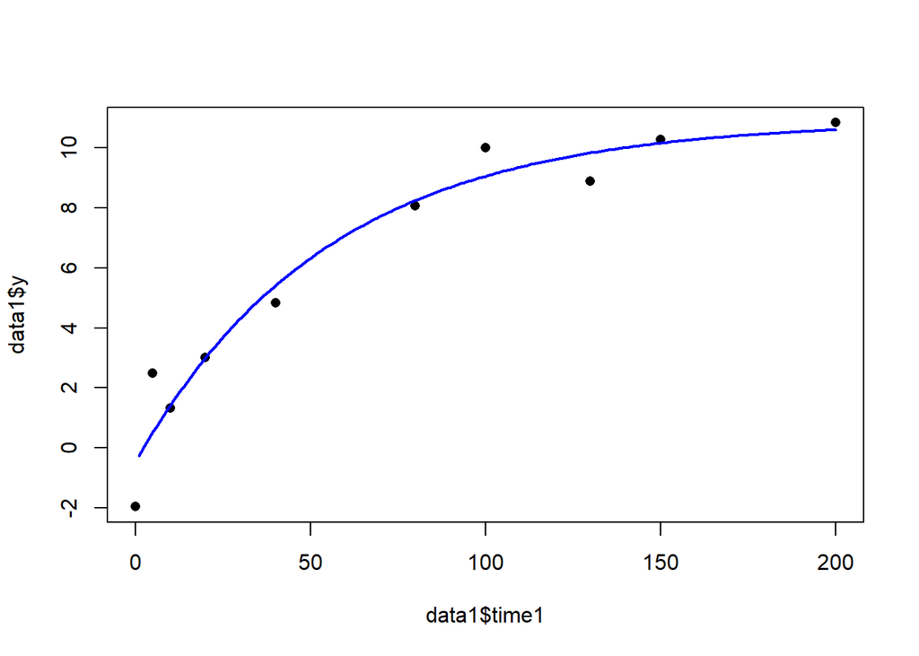

```r
nls1<-nlsfit(data1, model=9, start=c(10,1,0.01))
##9 = "y~a*(1-b*(exp(-c*x)))" brody
# 위의 식을 만족하는 a, b, c

x <- 1:200
y2 <- nls1$Parameters[1,]*(1-nls1$Parameters[2,]*(exp(-nls1$Parameters[3,]*x)))

plot(data1$time1, data1$y, pch=16) #자료 그림
lines(x,y2, col="blue", lwd=2) #추정된 선 추가
```

- 방법 2

```r
nlsfit(data1, model=12, start=c(0,10,0.01))
```

```
## $Model
## [1] "y ~ a + b * (1 - exp(-c * x))"
##
## $Parameters
##                                y
## coefficient a        -0.47559892
## coefficient b        11.37766258
## coefficient c         0.01820733
## p-value t.test for a  0.54983090
## p-value t.test for b  0.00001349
## p-value t.test for c  0.01363066
## r-squared             0.95340000
## adjusted r-squared    0.94000000
## AIC                  34.50837293
## BIC                  35.71871330
```

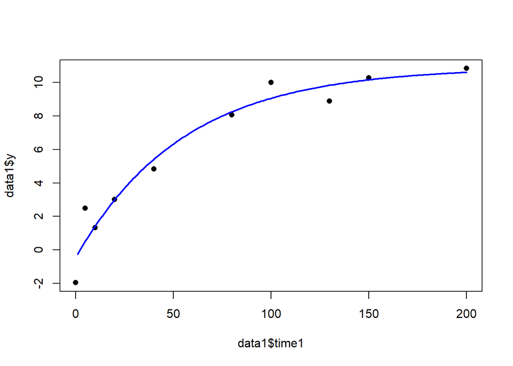

```r
nls2<-nlsfit(data1, model=12, start=c(0,10,0.01))
##12 = "y ~ a + b * (1 - exp(-c * x))" ruminal degradation curve
# 위의 식을 만족하는 a, b, c

x <- 1:200
y2 <- nls2$Parameters[1,] + nls2$Parameters[2,]*(1-exp(-nls2$Parameters[3,]*x))

plot(data1$time1, data1$y, pch=16) #자료 그림
lines(x,y2, col="blue", lwd=2) #추정된 선 추가
```

- 방법 3

```r
m=nls(y~a*(1-(exp(-b*time1))), data=data1, start=list(a=10,b=0.01),control = nls.control(maxiter = 6000))
coef(m)  #추정된 a, b 확인
```

```
##           a           b
## 11.16663449  0.01621864
```

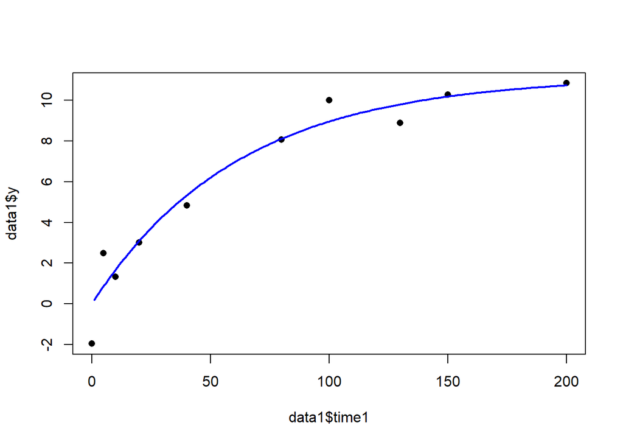

```r
a=coef(m)[1]
b=coef(m)[2]

x <- 1:200
y2 <- a*(1-(exp(-b*x)))

plot(data1$time1, data1$y, pch=16) #자료 그림
lines(x,y2, col="blue", lwd=2) #추정된 선 추가
```

- 다른 비선형모형의 fitting example
- data represent weights of an Angus cow at ages from 8 to 108 months (Kaps and Lamberson, 2009)

```r
weight=c(280,340,430,480,550,580,590,600,590,600)
age=c(8,12,24,36,48,60,72,84,96,108)

data1=data.frame(age, weight)

# linear
nlsfit(data1, model=1)
```

```
## $Model
## [1] "y~a+b*x"
##
## $Parameters
##                            weight
## coefficient a        339.46539517
## coefficient b          3.00245629
## p-value t.test for a   0.00000796
## p-value t.test for b   0.00044439
## r-squared              0.80350000
## adjusted r-squared     0.77890000
## AIC                  112.38217638
## BIC                  113.28993166
```

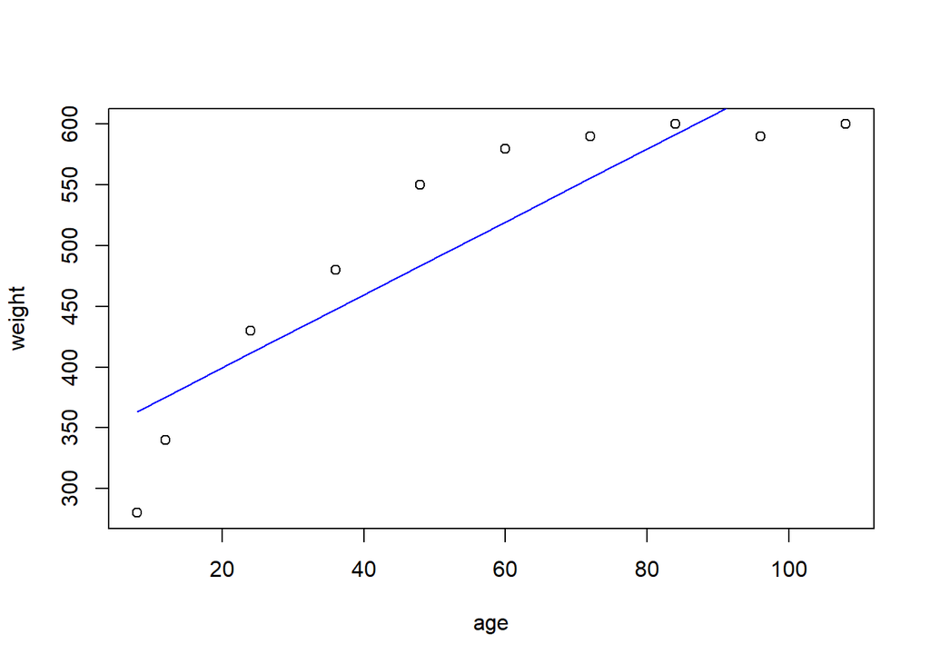

```r
m1<-nlsfit(data1, model=1)
pred<-m1$Parameters[1,]+m1$Parameters[2,]*age

plot(age, weight)
lines(age, pred, col="blue")
```

```r
# quadratic
nlsfit(data1, model=2)
```

```
## $Model
## [1] "y~a+b*x+c*x^2"
##
## $Parameters
##                                      weight
## coefficient a                  232.71504212
## coefficient b                    8.83418854
## coefficient c                   -0.05177807
## p-value t.test for a             0.00000068
## p-value t.test for b             0.00000149
## p-value t.test for c             0.00001995
## r-squared                        0.98740000
## adjusted r-squared               0.98380000
## AIC                             86.91453511
## BIC                             88.12487548
## maximum or minimum value for y 609.52943922
## critical point in x             85.30820806
```

```r
# linear plateau
nlsfit(data1, model=3)
```

```
## $Model
## [1] "y ~ a + b * (x - c) * (x <= c)"
##
## $Parameters
##                                      weight
## coefficient a                  592.00000000
## coefficient b                    6.38728325
## coefficient c                   53.15475108
## p-value t.test for a             0.00000000
## p-value t.test for b             0.00000232
## p-value t.test for c             0.00000012
## r-squared                        0.98690000
## adjusted r-squared               0.98310000
## AIC                             87.31095192
## BIC                             88.52129229
## maximum or minimum value for y 592.00000000
## critical point in x             53.15475108
```

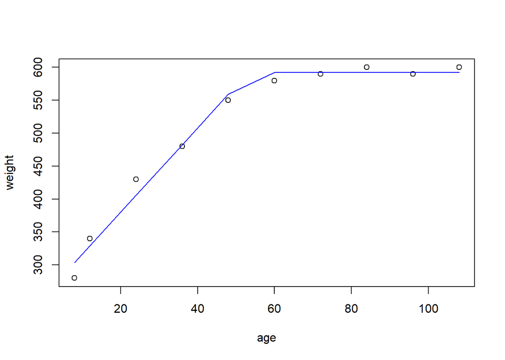

```r
m3<-nlsfit(data1, model=3)

pred <- m3$Parameters[1,]+ m3$Parameters[2,]*(age-m3$Parameters[3,])*(age <= m3$Parameters[3,])
plot(age, weight)
lines(age, pred, col="blue")
```

```r
# quadratic plateau
nlsfit(data1, model=4)
```

```
## $Model
## [1] "y ~ (a + b * x + c * I(x^2)) * (x <= -0.5 * b/c) + (a + I(-b^2/(4 * c))) * (x > -0.5 * b/c)"
##
## $Parameters
##                                      weight
## coefficient a                  216.00219479
## coefficient b                   10.12846154
## coefficient c                   -0.06764736
## p-value t.test for a             0.00000027
## p-value t.test for b             0.00000114
## p-value t.test for c             0.00003697
## r-squared                        0.99450000
## adjusted r-squared               0.99290000
## AIC                             78.63084723
## BIC                             79.84118760
## maximum or minimum value for y 595.12169249
## critical point in x             74.86220807
```

```r
# two linear
nlsfit(data1, model=5, start=c(250,6,2,50))
```

```
## $Model
## [1] "ifelse(x>=d,(a-c*d)+(b+c)*x, a+b*x)"
##
## $Parameters
##                            weight
## coefficient a        244.16666514
## coefficient b          6.91666674
## coefficient c         -6.22619056
## coefficient d         46.09177795
## p-value t.test for a   0.00000794
## p-value t.test for b   0.00009831
## p-value t.test for c   0.00028723
## p-value t.test for d   0.00002559
## r-squared              0.98660000
## adjusted r-squared     0.98000000
## AIC                   89.50008275
## BIC                   91.01300822
```

```r
# exponential
nlsfit(data1, model=6, start=c(250,0.05))
```

```
## $Model
## [1] "y~a*exp(b*x)"
##
## $Parameters
##                            weight
## coefficient a        368.26175362
## coefficient b          0.00545208
## p-value t.test for a   0.00000367
## p-value t.test for b   0.00194327
## r-squared              0.74110000
## adjusted r-squared     0.70870000
## AIC                  115.14119660
## BIC                  116.04895188
```

```r
# logistic
nlsfit(data1, model=7, start=c(600,4,0.05))
```

```
## $Model
## [1] "y~a*(1+b*(exp(-c*x)))^-1"
##
## $Parameters
##                            weight
## coefficient a        602.88895990
## coefficient b          1.69530231
## coefficient c          0.05786486
## p-value t.test for a   0.00000000
## p-value t.test for b   0.00000302
## p-value t.test for c   0.00000391
## r-squared              0.99310000
## adjusted r-squared     0.99110000
## AIC                   80.92626339
## BIC                   82.13660376
```

```r
# van bertalanffy
nlsfit(data1, model=8, start=c(600,2,0.05))
```

```
## $Model
## [1] "y~a*(1-b*(exp(-c*x)))^3"
##
## $Parameters
##                            weight
## coefficient a        608.61970116
## coefficient b          0.31654121
## coefficient c          0.04435102
## p-value t.test for a   0.00000000
## p-value t.test for b   0.00000025
## p-value t.test for c   0.00000943
## r-squared              0.99290000
## adjusted r-squared     0.99080000
## AIC                   81.21908676
## BIC                   82.42942713
```

```r
# brody
nlsfit(data1, model=9, start=c(600,4,0.05))
```

```
## $Model
## [1] "y~a*(1-b*(exp(-c*x)))"
##
## $Parameters
##                            weight
## coefficient a        612.86560207
## coefficient b          0.72723112
## coefficient c          0.03795803
## p-value t.test for a   0.00000000
## p-value t.test for b   0.00000008
## p-value t.test for c   0.00002264
## r-squared              0.99220000
## adjusted r-squared     0.99000000
## AIC                   82.08345345
## BIC                   83.29379382
```

```r
# gompertz
nlsfit(data1, model=10, start=c(600,4,0.05))
```

```
## $Model
## [1] "y~a*exp(-b*exp(-c*x)"
##
## $Parameters
##                            weight
## coefficient a        606.90009434
## coefficient b          1.09154807
## coefficient c          0.04763903
## p-value t.test for a   0.00000000
## p-value t.test for b   0.00000046
## p-value t.test for c   0.00000683
## r-squared              0.99300000
## adjusted r-squared     0.99110000
## AIC                   80.97293523
## BIC                   82.18327560
```